# Student-Performance-Analysis

SharanJC

2026-09-04

## Project Overview

Analysis on student performance, and study habits data set to explore how part-time employment may influence in students study, sleep hours and academic grades. The analysis focuses on identifying patterns and relationships between these factors. Exploratory data analysis, visualizations, correlation analysis, and regression modelling are used to compare students with and without part-time jobs and to examine whether work commitments may affect the balance between study, sleep and academic achievement.

## Reserach Question

### How does having a part-time job influence students study hours, sleep duration, & academic performance?

## Dataset Overview

The data set contains approximately 1,000 rows of information relating to students academic performance, study habits, and aspects of their daily lives. The variables used in this analysis are part_time_job, final_grade, sleep_hours and study_time_hours. There are two categorical variables, part_time_job and final_grade, and two numerical variables, study_time_hours and sleep_hours. The part_time_job variable has two categories, Yes and No, indicating whether a student has a part-time job. The final_grade variable is an ordered categorical variable ranging from A to F, representing students academic Performance.

### Required Libraries

```r
library(tidyverse)
library(ggplot2)
library(dplyr)
library(readxl)
library(MASS)

# library(corrplot)
# library(broom)
#install.packages("vcd")
```

### Dataset Import

```r
student_data <- read_csv("student-performance-data.csv")
```

#### Understanding the Dataset

```r
head(student_data)
```

```
## # A tibble: 6 × 12
##   student_id gender study_time_hours attendance_percent sleep_hours
##        <dbl> <chr>             <dbl>              <dbl>       <dbl>
## 1          1 Male                4                 98           6.5
## 2          2 Female              6.3              100           5.7
## 3          3 Male                4.9               85.3         7.9
## 4          4 Male                2.6               77.5         8
## 5          5 Male                2.2               89.6         4.6
## 6          6 Female              4.2               78.2         5.7
## # ℹ 7 more variables: parental_education <chr>, internet_access <chr>,
## #   extracurricular_activities <chr>, part_time_job <chr>,
## #   previous_grade <dbl>, final_exam_score <dbl>, final_grade <chr>
```

```r
# Summary of first few rows of dataset
summary(student_data)
```

```
##    student_id           gender     study_time_hours attendance_percent
##  Min.   :   1.0   Length   :1000   Min.   :0.500    Min.   : 54.80
##  1st Qu.: 250.8   N.unique :   2   1st Qu.:2.600    1st Qu.: 78.80
##  Median : 500.5   N.blank  :   0   Median :3.600    Median : 85.20
##  Mean   : 500.5   Min.nchar:   4   Mean   :3.571    Mean   : 85.09
##  3rd Qu.: 750.2   Max.nchar:   6   3rd Qu.:4.500    3rd Qu.: 91.90
##  Max.   :1000.0                    Max.   :8.100    Max.   :100.00
##   sleep_hours   parental_education  internet_access extracurricular_activities
##  Min.   : 3.2   Length   :1000     Length   :1000   Length   :1000
##  1st Qu.: 5.9   N.unique :   5     N.unique :   2   N.unique :   2
##  Median : 6.8   N.blank  :   0     N.blank  :   0   N.blank  :   0
##  Mean   : 6.8   Min.nchar:   3     Min.nchar:   2   Min.nchar:   2
##  3rd Qu.: 7.6   Max.nchar:  11     Max.nchar:   3   Max.nchar:   3
##  Max.   :10.0
##    part_time_job  previous_grade   final_exam_score    final_grade
##  Length   :1000   Min.   : 31.30   Min.   : 46.80   Length   :1000
##  N.unique :   2   1st Qu.: 61.00   1st Qu.: 76.08   N.unique :   5
##  N.blank  :   0   Median : 69.60   Median : 83.80   N.blank  :   0
##  Min.nchar:   2   Mean   : 69.74   Mean   : 83.54   Min.nchar:   1
##  Max.nchar:   3   3rd Qu.: 78.40   3rd Qu.: 91.53   Max.nchar:   1
##                   Max.   :100.00   Max.   :100.00
```

```r
# Summary Stats of selected variables
student_data |>
  dplyr::select(study_time_hours, sleep_hours, part_time_job, final_grade)|>
  summary()
```

```
##  study_time_hours  sleep_hours     part_time_job     final_grade
##  Min.   :0.500    Min.   : 3.2   Length   :1000   Length   :1000
##  1st Qu.:2.600    1st Qu.: 5.9   N.unique :   2   N.unique :   5
##  Median :3.600    Median : 6.8   N.blank  :   0   N.blank  :   0
##  Mean   :3.571    Mean   : 6.8   Min.nchar:   2   Min.nchar:   1
##  3rd Qu.:4.500    3rd Qu.: 7.6   Max.nchar:   3   Max.nchar:   1
##  Max.   :8.100    Max.   :10.0
```

```r
# (Rows, Columns)
dim(student_data)
```

```
## [1] 1000   12
```

```r
# Name of all Columns
names(student_data)
```

```
##  [1] "student_id"                 "gender"
##  [3] "study_time_hours"           "attendance_percent"
##  [5] "sleep_hours"                "parental_education"
##  [7] "internet_access"            "extracurricular_activities"
##  [9] "part_time_job"              "previous_grade"
## [11] "final_exam_score"           "final_grade"
```

## Data Cleaning and Preparation

#### Missing & Duplicated Values Analysis

```r
# Check for missing data
sum(is.na(student_data))
```

```
## [1] 0
```

```r
sum(student_data %in% c("", " ", "_", "?"), na.rm = TRUE)
```

```
## [1] 0
```

```r
# Check for Duplicates
sum(duplicated(student_data))
```

```
## [1] 0
```

#### Variable Conversion and Ordering

```r
# Convert part time job (yes & no) to a categorical variable
student_data$part_time_job <- as.factor(student_data$part_time_job)

# Convert final_grade to a categorical variable
student_data$final_grade <- as.factor(student_data$final_grade)

levels(student_data$final_grade)
```

```
## [1] "A" "B" "C" "D" "F"
```

```r
student_data$final_grade <- factor(student_data$final_grade, levels=c("A", "B","C","D","E","F"), order = FALSE)
```

## Exploratory Data Analysis

```r
# Bar graph of students who have (yes) and have not(no) part time jobs

# Number of students part time jobs status
table(student_data$part_time_job)
```

```
##
##  No Yes
## 684 316
```

```r
prop.table(table(student_data$part_time_job)) *100
```

```
##
##   No  Yes
## 68.4 31.6
```

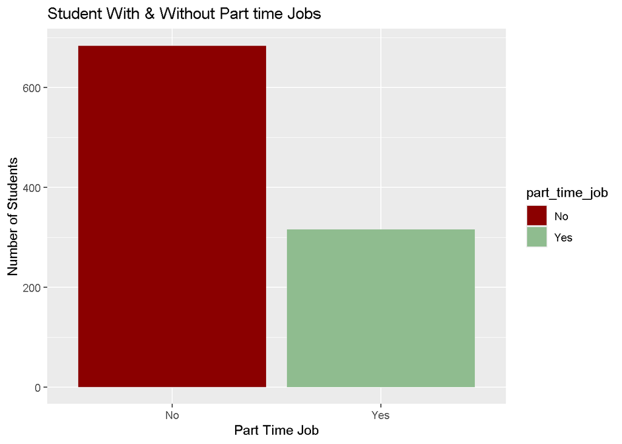

```r
# Plot Graph
ggplot(student_data,aes(x=part_time_job, fill = part_time_job)) +
  geom_bar()+
  scale_fill_manual(values = c("No"="darkred", "Yes"="darkseagreen"))+
  labs(
    title = "Student With & Without Part time Jobs",
    x = "Part Time Job",
    y = "Number of Students"
  )
```

```r
# Histogram of Students Study Duration
summary(student_data$study_time_hours)
```

```
##    Min. 1st Qu.  Median    Mean 3rd Qu.    Max.
##   0.500   2.600   3.600   3.571   4.500   8.100
```

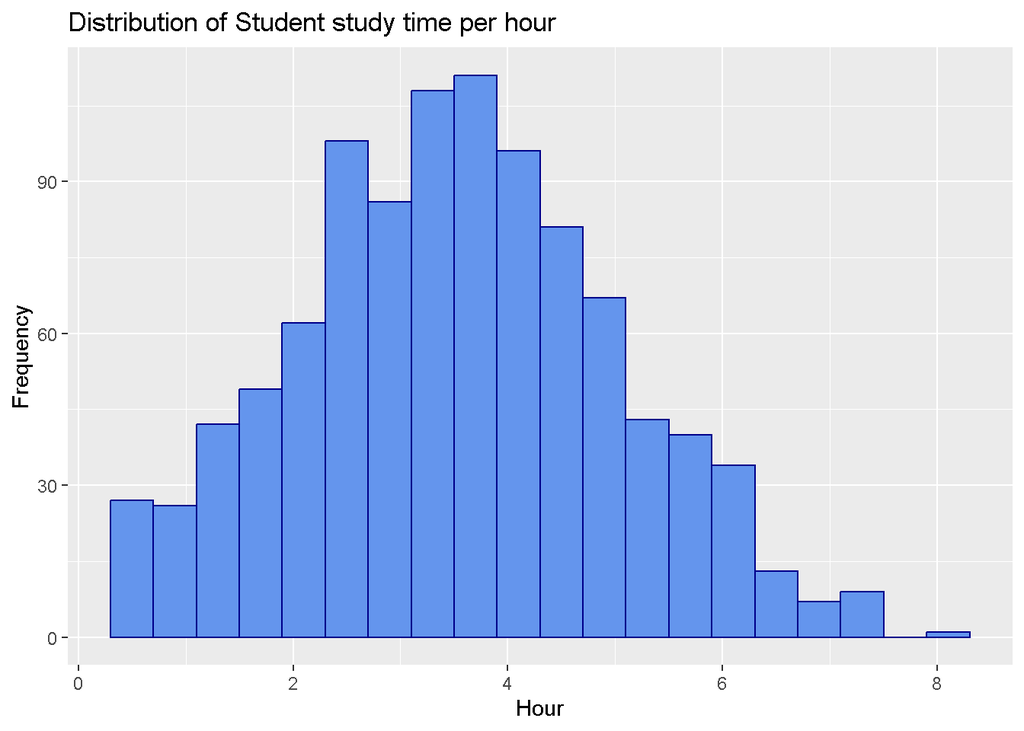

```r
ggplot(student_data,aes(x = study_time_hours))+
  geom_histogram(bins=20, fill = "cornflowerblue", color="darkblue")+
  labs(
    title = "Distribution of Student study time per hour",
    x = "Hour",
    y = "Frequency"
  )
```

```r
# Histogram of Student Sleep Hours
summary(student_data$sleep_hours)
```

```
##    Min. 1st Qu.  Median    Mean 3rd Qu.    Max.
##     3.2     5.9     6.8     6.8     7.6    10.0
```

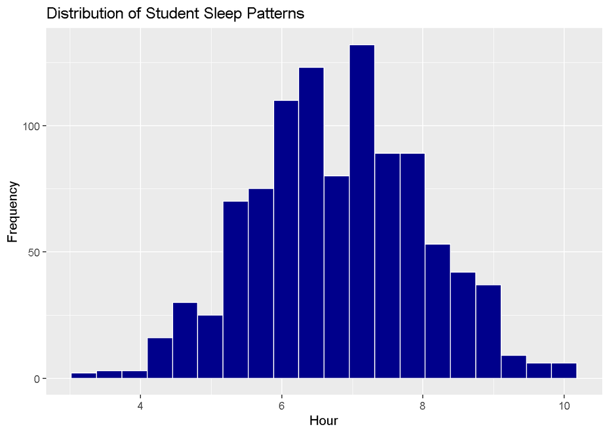

```r
ggplot(student_data,aes(x = sleep_hours))+
  geom_histogram(bins=20, fill = "darkblue", color="white")+
  labs(
    title="Distribution of Student Sleep Patterns",
    x="Hour",
    y="Frequency"
  )
```

```r
# Bar graph of Students final grades
summary(student_data$final_grade)
```

```
##   A   B   C   D   E   F
## 284 354 261  89   0  12
```

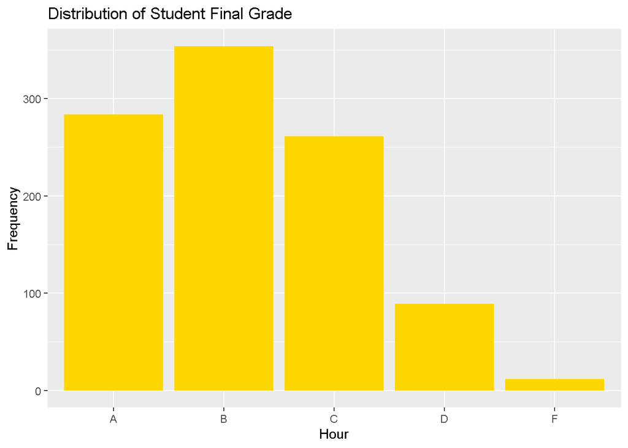

```r
ggplot(student_data,aes(x = final_grade))+
  geom_bar(bins=20, fill = "gold")+
  labs(
    title="Distribution of Student Final Grade",
    x="Hour",
    y="Frequency"
  )
```

### Visual Comparison of Selected Variables

```r
# Group students average by whether they have a part-time job
student_data |>
  group_by(part_time_job)|>
  summarise(
    avg_study_Hr = round(mean(study_time_hours, na.rm=TRUE), 2),
    avg_sleep_Hr = round(mean(sleep_hours, na.rm=TRUE), 2)
  )
```

```
## # A tibble: 2 × 3
##   part_time_job avg_study_Hr avg_sleep_Hr
##   <fct>                <dbl>        <dbl>
## 1 No                    3.59         6.79
## 2 Yes                   3.53         6.82
```

```r
# Percentage & sum of students part time job status to final grade
student_data |>
  count(part_time_job, final_grade) |>
  group_by(part_time_job) |>
  mutate (Percentage = round(n / sum(n) * 100,2)) |>
  ungroup()
```

```
## # A tibble: 10 × 4
##    part_time_job final_grade     n Percentage
##    <fct>         <fct>       <int>      <dbl>
##  1 No            A             213      31.1
##  2 No            B             245      35.8
##  3 No            C             180      26.3
##  4 No            D              41       5.99
##  5 No            F               5       0.73
##  6 Yes           A              71      22.5
##  7 Yes           B             109      34.5
##  8 Yes           C              81      25.6
##  9 Yes           D              48      15.2
## 10 Yes           F               7       2.22
```

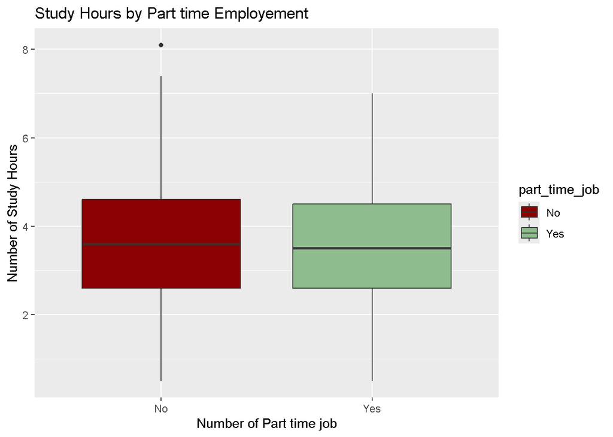

```r
# Box plot of students who study hours and part time job status
ggplot(student_data, aes(x = part_time_job, y=study_time_hours, fill = part_time_job )) +
  geom_boxplot()+
  scale_fill_manual(values = c("No"="darkred", "Yes"="darkseagreen"))+
  labs(
    title = "Study Hours by Part time Employement",
    x = "Number of Part time job",
    y= "Number of Study Hours"
  )
```

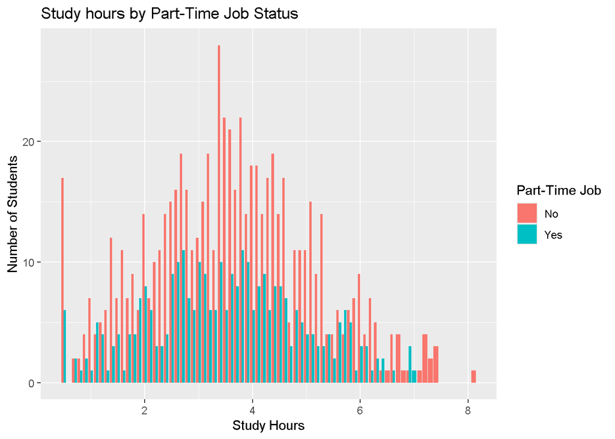

```r
# Bar graph students who study hours and part time job status
ggplot(student_data, aes(x = study_time_hours, fill = part_time_job)) +
  geom_bar(position = "dodge") +
  labs(
    title = "Study hours by Part-Time Job Status",
    x = "Study Hours",
    y = "Number of Students",
    fill = "Part-Time Job"
  )
```

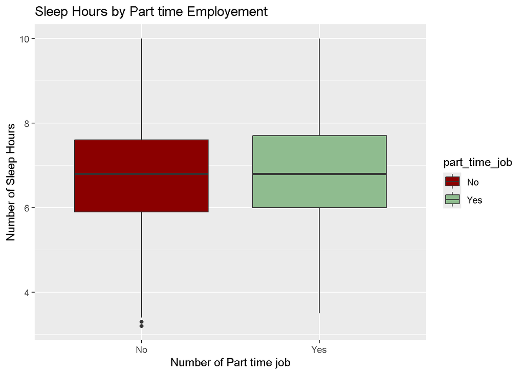

```r
# Box plot of students who Sleep hours and part time job status
ggplot(student_data, aes(x = part_time_job, y=sleep_hours, fill = part_time_job )) +
  geom_boxplot()+
  scale_fill_manual(values = c("No"="darkred", "Yes"="darkseagreen"))+
  labs(
    title = "Sleep Hours by Part time Employement",
    x = "Number of Part time job",
    y= "Number of Sleep Hours"
  )
```

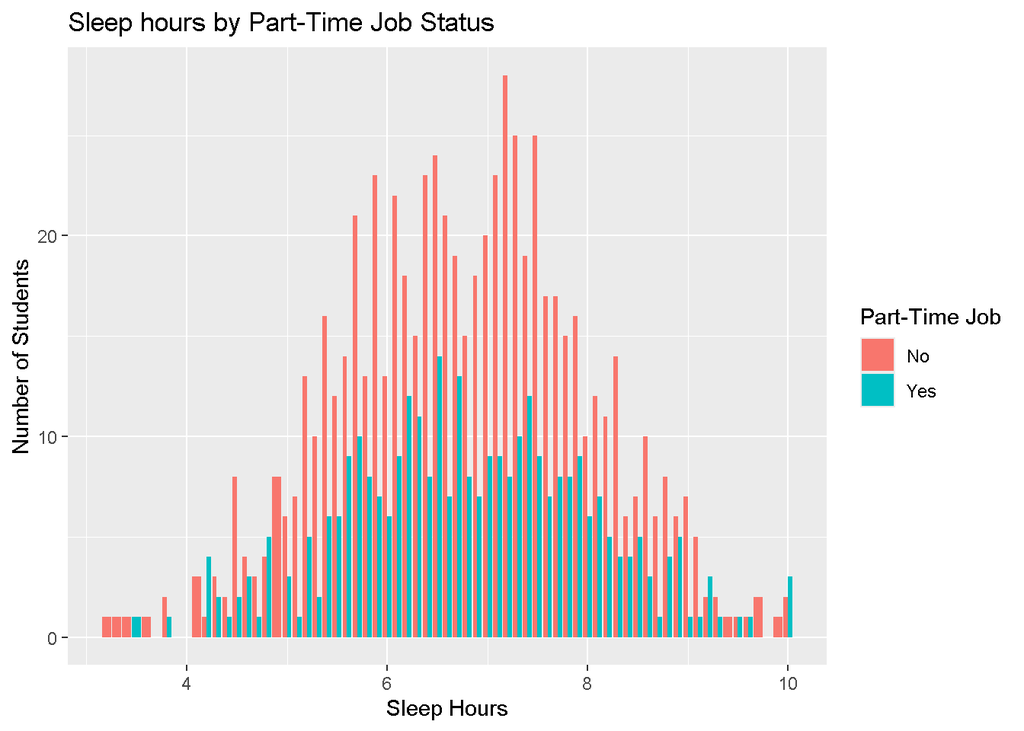

```r
# Bar graph students who sleep hours and part time job status
ggplot(student_data, aes(x = sleep_hours, fill = part_time_job)) +
  geom_bar(position = "dodge")+
  labs(
    title = "Sleep hours by Part-Time Job Status",
    x = "Sleep Hours",
    y = "Number of Students",
    fill = "Part-Time Job"
  )
```

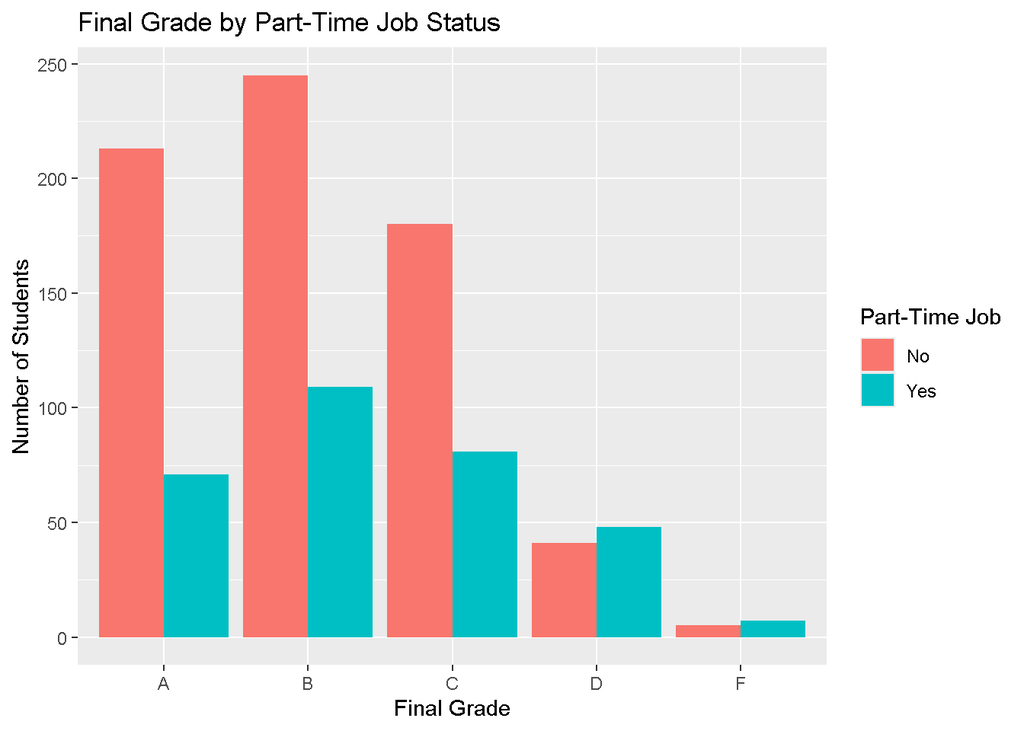

```r
# Bar graph students who final grade and part time job status
ggplot(student_data, aes(x = final_grade, fill = part_time_job)) +
  geom_bar(position = "dodge") +
  labs(
    title = "Final Grade by Part-Time Job Status",
    x = "Final Grade",
    y = "Number of Students",
    fill = "Part-Time Job"
  )
```

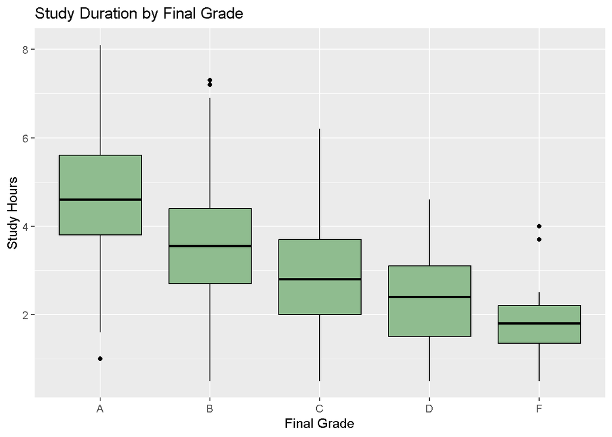

```r
# Compare the distribution of study hours across final grade categories
ggplot(student_data, aes(x = final_grade, y = study_time_hours)) +
  geom_boxplot(fill = "darkseagreen", color = "black") +
  labs(
    title = "Study Duration by Final Grade",
    x = "Final Grade",
    y = "Study Hours"
  )
```

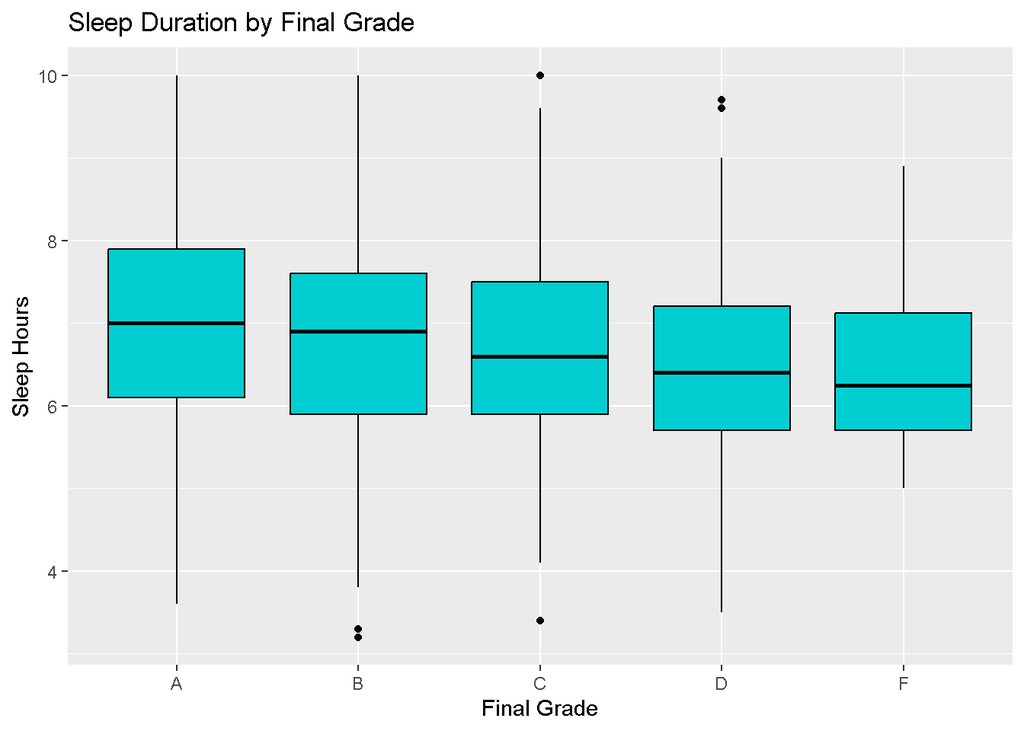

```r
# Compare the distribution of sleep hours across final grade categories
ggplot(student_data, aes(x = final_grade, y = sleep_hours)) +
  geom_boxplot(fill = "darkturquoise", color = "black") +
  labs(
    title = "Sleep Duration by Final Grade",
    x = "Final Grade",
    y = "Sleep Hours"
  )
```

## Comparative Analysis of Group Averages

```r
# ==========================================================================
# Average of students final grades with relation to study & sleep hours
student_data |>
  group_by(final_grade)|>
  summarise(
    avg_studyHr = round(mean(study_time_hours, na.rm=TRUE),2),
    avg_sleepHr = round(mean(sleep_hours, na.rm=TRUE),2)
  )
```

```
## # A tibble: 5 × 3
##   final_grade avg_studyHr avg_sleepHr
##   <fct>             <dbl>       <dbl>
## 1 A                  4.65        7.02
## 2 B                  3.59        6.8
## 3 C                  2.88        6.69
## 4 D                  2.3         6.45
## 5 F                  1.98        6.46
```

```r
# ==========================================================================
# Comparison of students part-time job status relation to students study & sleep hours average
student_data |>
  group_by(part_time_job)|>
  summarise(
    avg_studyHr = round(mean(study_time_hours, na.rm=TRUE),2),
    avg_sleepHr = round(mean(sleep_hours, na.rm=TRUE),2)
  )
```

```
## # A tibble: 2 × 3
##   part_time_job avg_studyHr avg_sleepHr
##   <fct>               <dbl>       <dbl>
## 1 No                   3.59        6.79
## 2 Yes                  3.53        6.82
```

```r
# ==========================================================================
# Compare average study and sleep hours by final grade and part-time job status
student_data |>
  summarise( .by = c(final_grade, part_time_job),
    avg_studyHr = round(mean(study_time_hours, na.rm=TRUE),2),
    avg_sleepHr = round(mean(sleep_hours, na.rm=TRUE),2)
  )
```

```
## # A tibble: 10 × 4
##    final_grade part_time_job avg_studyHr avg_sleepHr
##    <fct>       <fct>               <dbl>       <dbl>
##  1 A           No                   4.62        7
##  2 A           Yes                  4.71        7.08
##  3 B           No                   3.57        6.75
##  4 D           Yes                  2.35        6.33
##  5 C           No                   2.76        6.64
##  6 B           Yes                  3.64        6.92
##  7 C           Yes                  3.14        6.79
##  8 D           No                   2.25        6.59
##  9 F           No                   1.34        6.9
## 10 F           Yes                  2.43        6.14
```

## Spearman Correlation Analysis & Independent Samples t-Test

```r
# Correlation between final grade and study hour
cor(student_data$study_time_hours,as.numeric(student_data$final_grade), method="spearman", use="complete.obs")
```

```
## [1] -0.5315147
```

```r
# Correlation between final grade and sleep hour
cor(student_data$sleep_hours, as.numeric(student_data$final_grade), method="spearman",use="complete.obs")
```

```
## [1] -0.1418226
```

```r
#============================================================================================================

# Test on study Hour vs part time Status
t.test(study_time_hours ~ part_time_job, student_data)
```

```
##
##  Welch Two Sample t-test
##
## data:  study_time_hours by part_time_job
## t = 0.60994, df = 639.14, p-value = 0.5421
## alternative hypothesis: true difference in means between group No and group Yes is not equal to 0
## 95 percent confidence interval:
##  -0.1339141  0.2545855
## sample estimates:
##  mean in group No mean in group Yes
##          3.589766          3.529430
```

```r
# Test on sleep Hour vs part time status
t.test(sleep_hours ~ part_time_job, student_data)
```

```
##
##  Welch Two Sample t-test
##
## data:  sleep_hours by part_time_job
## t = -0.30175, df = 608.38, p-value = 0.7629
## alternative hypothesis: true difference in means between group No and group Yes is not equal to 0
## 95 percent confidence interval:
##  -0.1861204  0.1365423
## sample estimates:
##  mean in group No mean in group Yes
##          6.791667          6.816456
```

## Ordinal Logistic Regression Model

```r
# Create model
model_1 <-summary(polr(final_grade ~ study_time_hours +sleep_hours + part_time_job, student_data, Hess=TRUE))
# Print summary model
model_1
```

```
## Call:
## polr(formula = final_grade ~ study_time_hours + sleep_hours +
##     part_time_job, data = student_data, Hess = TRUE)
##
## Coefficients:
##                    Value Std. Error t value
## study_time_hours -0.8201    0.04822 -17.007
## sleep_hours      -0.2719    0.05095  -5.336
## part_time_jobYes  0.6569    0.13052   5.033
##
## Intercepts:
##     Value    Std. Error t value
## A|B  -5.7810   0.4193   -13.7869
## B|C  -3.8066   0.3952    -9.6316
## C|D  -1.8111   0.3859    -4.6927
## D|E   0.5882   0.4654     1.2638
## E|F   0.5886   0.4655     1.2645
##
## Residual Deviance: 2305.654
## AIC: 2321.654
```

```r
# Create model
model_2 <-summary(polr(final_grade ~ study_time_hours * part_time_job +sleep_hours * part_time_job, student_data, Hess=TRUE))

# Print summary model
model_2
```

```
## Call:
## polr(formula = final_grade ~ study_time_hours * part_time_job +
##     sleep_hours * part_time_job, data = student_data, Hess = TRUE)
##
## Coefficients:
##                                      Value Std. Error t value
## study_time_hours                  -0.79052    0.05555 -14.231
## part_time_jobYes                   1.97124    0.82715   2.383
## sleep_hours                       -0.22667    0.06107  -3.712
## study_time_hours:part_time_jobYes -0.09739    0.09305  -1.047
## part_time_jobYes:sleep_hours      -0.14324    0.10875  -1.317
##
## Intercepts:
##     Value    Std. Error t value
## A|B  -5.3758   0.4855   -11.0725
## B|C  -3.4038   0.4651    -7.3189
## C|D  -1.3945   0.4618    -3.0197
## D|E   1.0293   0.5366     1.9182
## E|F   1.0294   0.5366     1.9184
##
## Residual Deviance: 2302.865
## AIC: 2322.865
```

## Conclusion

### How does having a part-time job influence students study hours, sleep duration, & academic performance?

The two sample t-test found no statistically significance difference in study hours between students with and without part-time jobs (p = 0.5421). Students without part-time jobs studied an average of 3.59 hours compared with 3.53 hours for students with a part-time job. Similarly, there was no statistically significant difference in sleep duration (p= 0.7629) with average of 6.79 hours for students without a job and 6.82 hours for students with a job. These findings tell us that having a part-time job was not associated with a meaningful difference in the amount of time students spent studying or sleeping.

The ordinal logistic regression provided further evidence that study time was strongly associated with final grade(t = -14.231), while sleep duration also showed an association (t = -3.712). Part-time job status had a coefficient with a t-value of 2.383. The relation between part-time job status and study hours ( t = -1.047) and the relation between part-time job and sleep duration (t = -1.317) were both below the approximate $\pm$ 1.96 significance threshold. Therefore there was little evidence that having a part-time job significantly affected the relationship between study or sleep hours and academic performance.

In conclusion study hours appear to have the strongest relationship with academic performance, while sleep duration has a weaker relationship. Students having a part-time job doe not appear to change or affect students sleep or study duration, nor does it strongly change how those factors relate to final grades.